# 罰則付き回帰モデル

川田恵介

# 罰則付き回帰モデル

- $X$ の数が多い場合、線形予測モデルの推定は困難
- 決定木(RandomForest)は有力な代替案だが、$X$ の数が極めて多くなると機能しなくなる
- 有力な選択肢は、線形予測モデル推定の改良

## 復習

- 線形予測モデル
  $$g(X)=\beta_0+..+\beta_LX_L$$
- データに当てはめるように推定
  - $\beta$ の数が多くなると、予測性能が悪化
  - 過剰適合

## イメージ

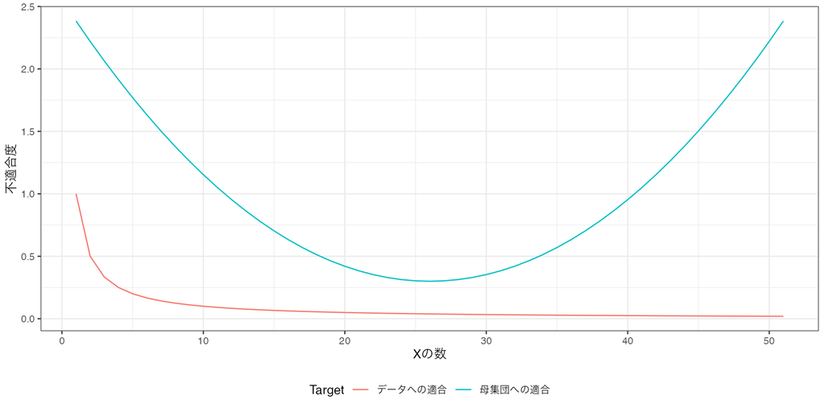

## 対応

- 環境税などと同じアイディア
- 自動車は便利な道具であるが、同時に排気ガス/渋滞など負の外部性が存在
  - 何も対応しないと保有台数が過大になりうる
- 適切な水準に誘導するために、自動車税を貸す
- **何も対応しないと複雑なモデルになりすぎるので、複雑性に課税する**

## 罰則付き回帰

- 線形モデル $g(X)$ を、以下を最小化するように推定する
  $$データへの当てはまり + \underbrace{\lambda\times 複雑性}_{複雑性への課税}$$
- $\lambda:$ 課税額
  - 交差推定で決定
  - 母集団の当てはまり最大化を目指す

## 複雑性の指標

- Ridge: $\beta_1^2+..+\beta_L^2$
- LASSO: $|\beta_1|+..+|\beta_L|$
- OLS: “0”

## LASSOの利点

- 予測において重要ではない$\beta$ を、厳密に0にできる
  - 重要ではない変数をモデルから除外する
- OLSやRidgeでは、厳密に0にはできない

## テキスト分析への有効性

- 単語数が多い $\rightarrow$ $X$ が多い $\rightarrow$ 重要ではない単語も多いかも?
- LASSOが有効な場面も多い

## 実例

```
13 x 1 sparse Matrix of class "dgCMatrix"
                     s0
(Intercept)  0.41657106
新型コロナ   .
行動        -0.06469847
経済         0.04837969
分析         .
危機         .
感染        -0.01021124
データ      -0.11531544
コロナ       .
ウイルス     .
影響         .
covid-19     .
企業         .
```

## 注意: 統計的推論

- 解釈しやすそうなモデルが出てくるが、
  - 母集団の構造への含意は限定的
- $Y$ と関係性が強い変数であったとしても、互いに相関が強ければ、脱落しがち
- 推定誤差の計算は困難

## 数値例

- $E[Y|X1,X2]=X1+X2$
- $E[X2|X1]=X1$

## 数値例

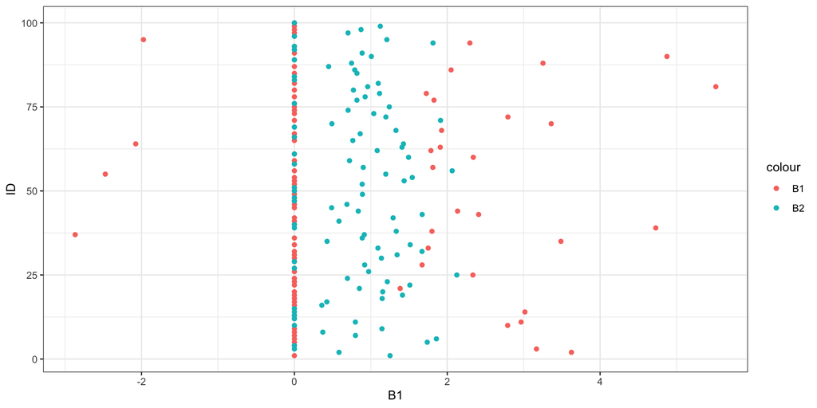

## まとめ

- 事例数を大きく超える $X$ から、予測モデルを構築することは困難なチャレンジ
  - 一つのアプローチは、LASSO
  - ただし解釈は慎重に

# 発展: ニューラルネット

- 線形モデルの拡張
- “人間の脳みその構造を模したモデル”
  - “AI”

## アイディア

- モデルの集計
1. 複数の中間予測モデル $g_1(X)..g_M(X)$ (Hidden Layer)を推定
2. 中間予測モデルの予測値から、最終予測モデル $g(g_1(X),..,g_M(X))$ を推定
- $g$ は一般化された線形モデル $g(X_1,..,X_L)=g(\beta_0+..+\beta_LX_L)$
- 中間モデルの数 $=$ 複雑性を規定

## 実例

[figure not shown]

## 実例

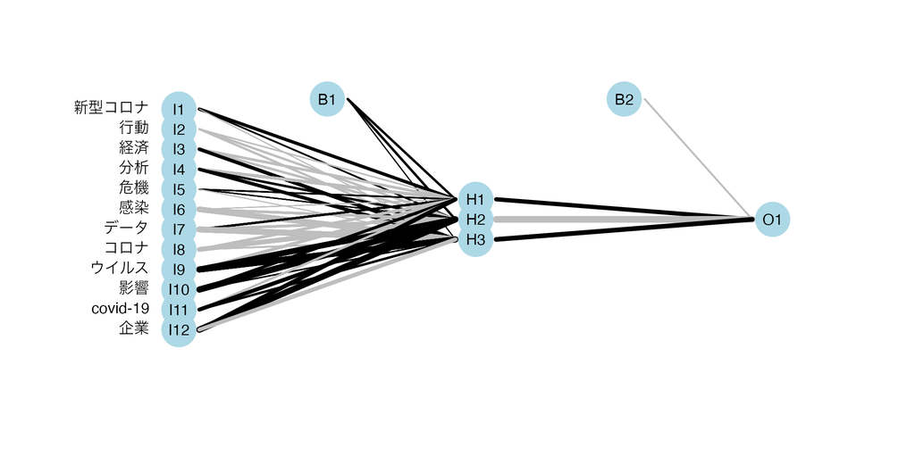

## 実例

```
Call:
CV.SuperLearner(Y = Y, X = X, SL.library = c("SL.mean", "SL.lm", "SL.glmnet",
    "SL.nnet"))

Risk is based on: Mean Squared Error

All risk estimates are based on V =  10

     Algorithm     Ave        se     Min     Max
 Super Learner 0.24395 0.0106424 0.19354 0.29386
   Discrete SL 0.24663 0.0085348 0.21099 0.28086
   SL.mean_All 0.24663 0.0085348 0.21099 0.28086
     SL.lm_All 0.27207 0.0208188 0.18744 0.39428
 SL.glmnet_All 0.25081 0.0090918 0.21530 0.30429
   SL.nnet_All 0.28481 0.0323231 0.14564 0.42045
```

## DeepLearning

- 中間予測モデルを多層にする
- 人間の脳の構造に似ているそうです。。。
  - テキストや画像データについて、高い精度

## 実例

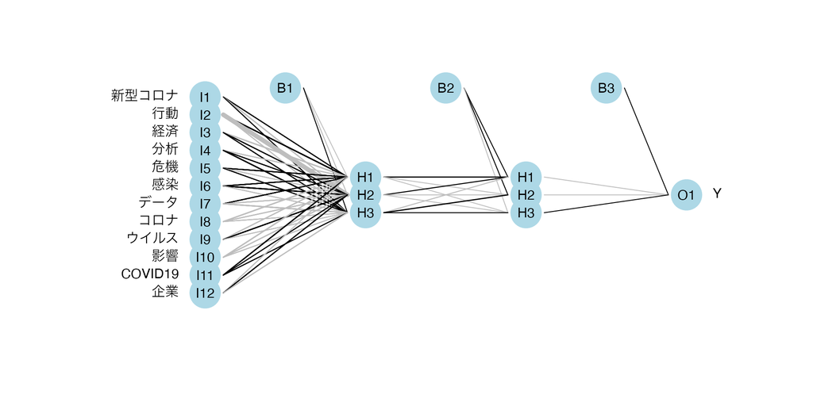

## 性能

```
Call:
SuperLearner(Y = Y, X = X, SL.library = c("SL.mean", "SL.lm", "SL.glmnet",
    "SL.nnet"))

                   Risk        Coef
SL.mean_All   0.2466307 0.995873301
SL.lm_All     0.3098022 0.000000000
SL.glmnet_All 0.2514735 0.000000000
SL.nnet_All   1.2454732 0.004126699
```

## まとめ

- 盛んに成果が報告される
  - 一部分野では非常に高いパフォーマンス
  - どの程度まで一般性があるかは不透明
- パラメータ設定が難しい